# R codebase（三）基础作图与ggplot2

#### 6.坐标轴

axis()

```r
axis(side,at = ,labels = ,pos = ,lty = ,col = ,Las=,tck=, ……)
```

| side | 整数，表示绘制坐标轴的位置（1=下，2=左，3=上，4=右） |
| --- | --- |
| at | 数值型向量，表示需要绘制刻度线的位置 |
| labels | 字符型向量，表示置于刻度线旁边的文字标签,(如果为Null，则默认使用at()中的值 |
| pos | 坐标轴线绘制位置的坐标(相交点的坐标)｜ |
| lty | 线条类型 |
| col | 线条颜色与刻度线颜色 |
| las | 标签是否平行于（=0）或垂直于（=2）坐标轴（标签值较长的情况） |
| tck | 刻度线长度，负数为外侧，正数为内侧，0表示禁用，1表示绘制网格线，默认-0.01 |

axes=FALSE 禁用坐标轴， yaxt=“n”,xaxt=“n” 分别禁用y轴和x轴

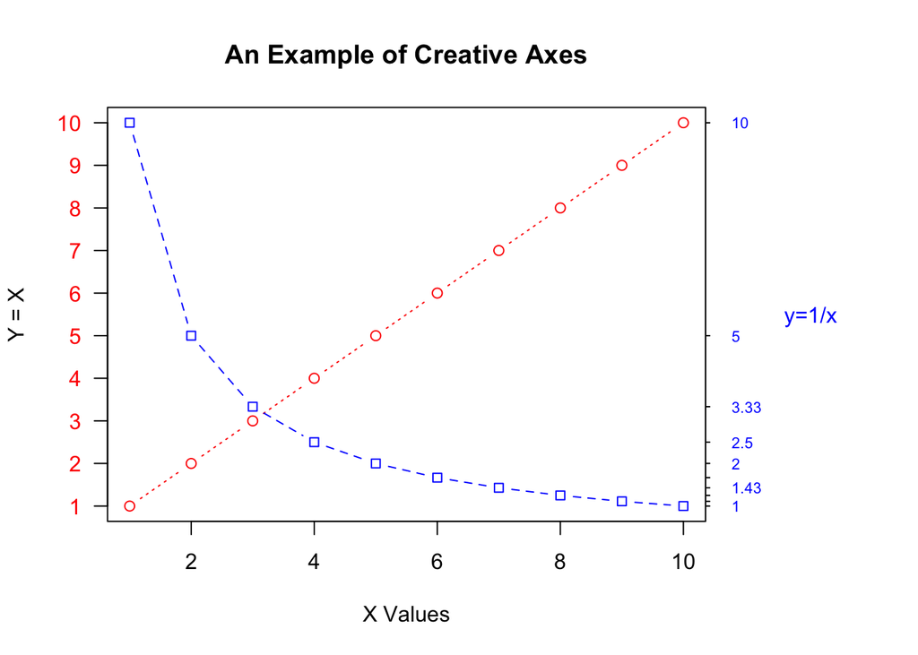

```r
## 举例

x <- c(1:10)
y <- x
z <- 10/x
opar <- par(no.readonly = T)

par(mar=c(5,4,4,8)+0.1)
plot(x,y,type="b",pch=21,col="red",yaxt="n",lty=3,ann=FALSE)
lines(x,z,type="b",pch=22,col="blue",lty=2)
axis(2,at=x,labels = x,col.axis="red",las=2)
axis(4,at=z,labels = round(z,digits = 2),col.axis="blue",las=2,cex.axis=0.7,tck=-0.01)
mtext("y=1/x",side=4,line=3,cex.lab=1,las=2,col="blue")
title("An Example of Creative Axes",xlab = "X Values",ylab = "Y = X")
```

```r
par(opar)
```

#### 7.参考线

abline(h=yvalues,v=xvalues)为图形添加参考线

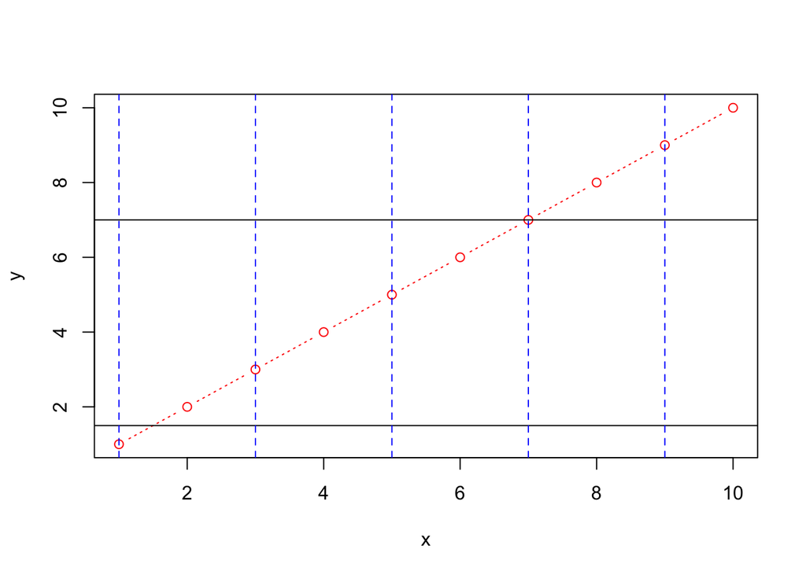

```r
plot(x,y,type="b",pch=21,col="red",lty=3)
abline(h=c(1.5,7))
abline(v=seq(1,10,2),lty=2,col="blue")
```

#### 8.图例

legend(location,title,legend,…)

| 选项 | 描述 |
| --- | --- |
| location | 1，指定坐标；2，使用关键字（bottom，topright 等），可同时使用inset=指定向图形内侧移动的大小 |
| title | 标题 |
| legend | 标签 |

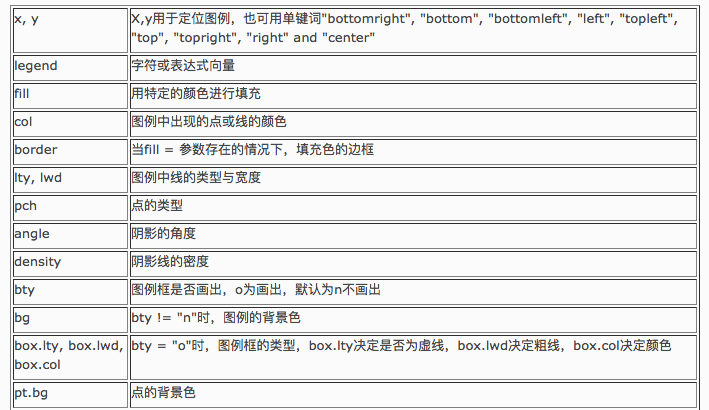

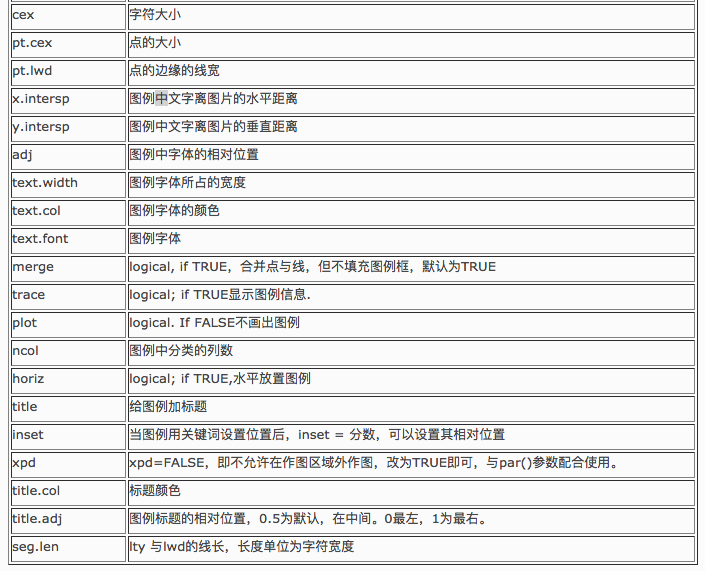

#### 9.文本标注

text(location,“text to place”,pos,…) mtext(“text to place”,side,line=n,…)

| 选项 | 描述 |
| --- | --- |
| location | 文本位置 |
| pos | 相对于位置的方位，1=下，2=左，3=上，4=右，使用offset=指定偏移量 |
| side | 文本的边，lines=内移或外移文本，adj=0文本左下对齐，adj=1右上对齐 |

```r
attach(mtcars)
```

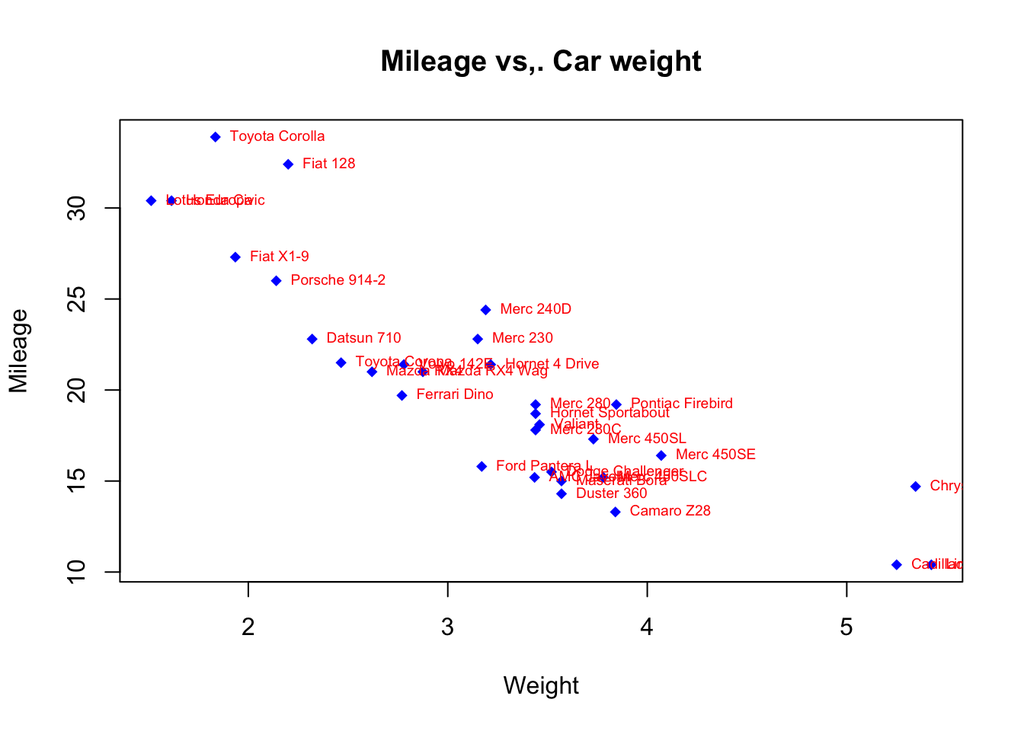

```r
plot(wt,mpg,
     main = "Mileage vs,. Car weight",
     xlab = "Weight",ylab = "Mileage",
     pch=18,col="blue")
text(wt,mpg,
     row.names(mtcars),
     cex=0.6,pos=4,col = "red")
```

```r
detach(mtcars)
```

#### 10.数学标注

plotmath()添加数学符号

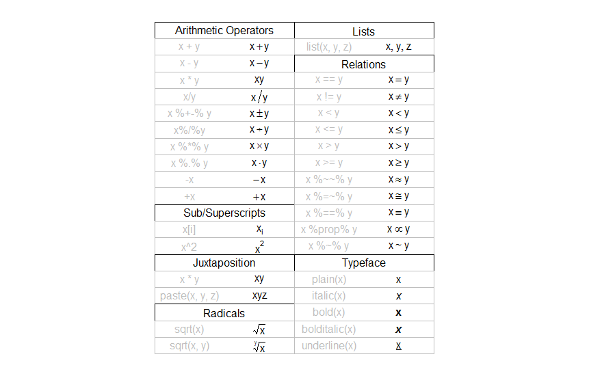

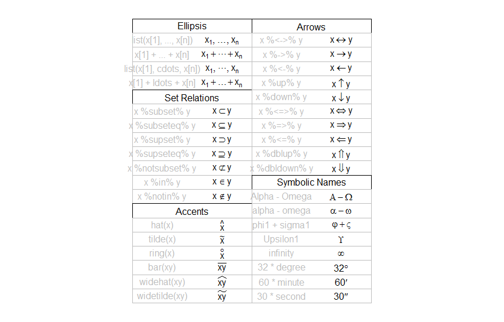

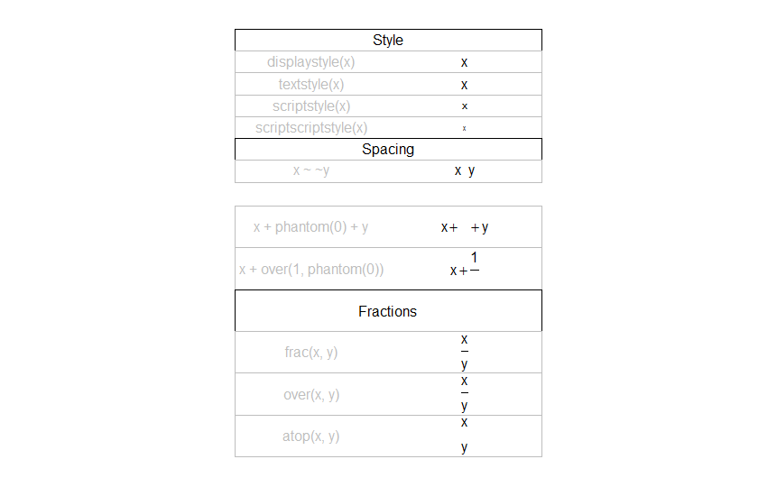

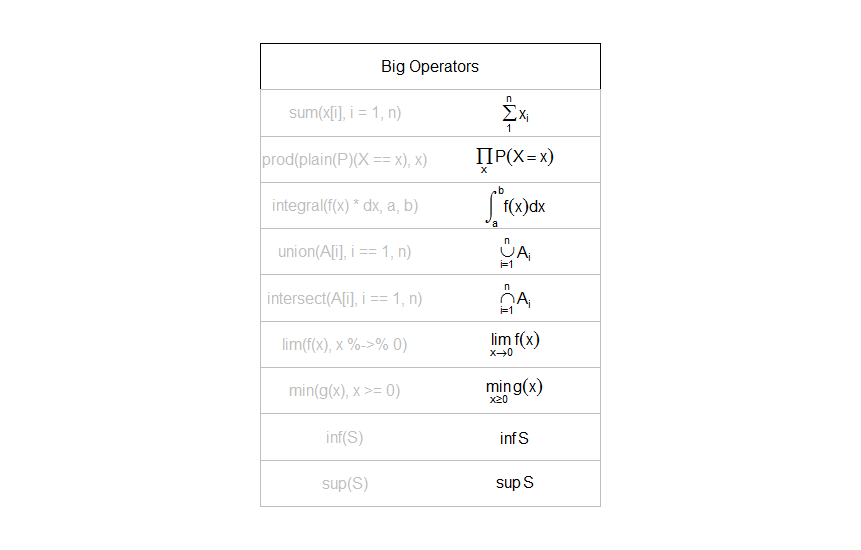

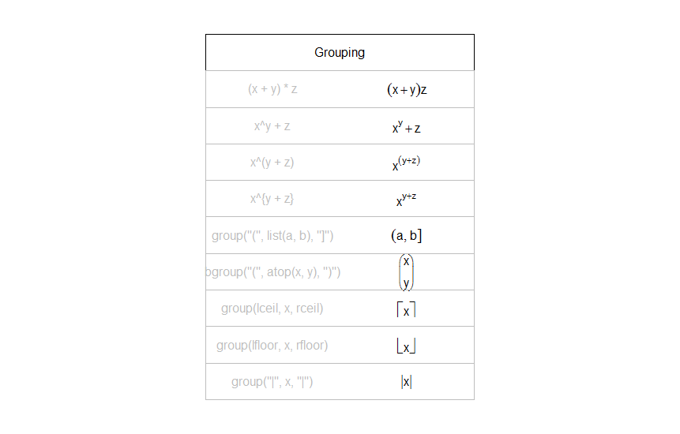

#### 11.图形的组合

- par()

使用参数mfrow=c(nrows,ncols) or mfcol=c(nrows,ncols)

```r
attach(mtcars)
```

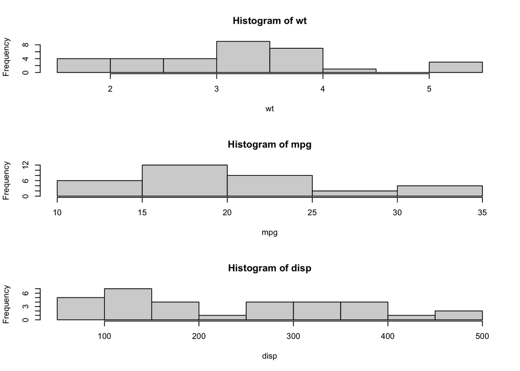

```r
opar <- par(no.readonly = T)
par(mfrow=c(3,1))
hist(wt)
hist(mpg)
hist(disp)
```

```r
par(opar)
detach(mtcars)
```

- layout()

layout(mat),使用mat指定图形位置（所在行）

```r
attach(mtcars)
```

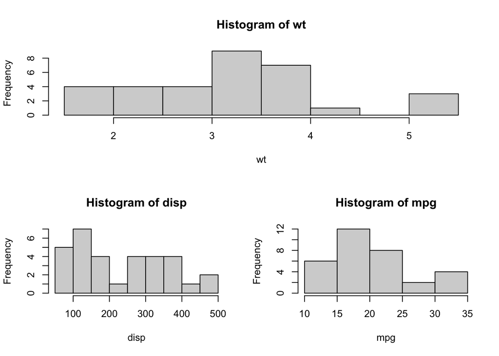

```r
layout(matrix(c(1,1,2,3),2,2,byrow = T))
hist(wt)
hist(disp)
hist(mpg)
```

```r
detach(mtcars)
```

#### 9.添加多边形

#### 10.平滑散点

#### 11.绘制显式表达式的函数

- 放大曲线的一部分

### 三维图形

## 二、ggplot2作图

### 基本图类型

### 分组

### 刻面

### 添加光滑曲线

### 外观修改

#### 1.坐标轴

#### 2.图例

#### 3.标尺

#### 4.主题

#### 5.多重图

### 图形保存

> 持续更新 。。。